# Integrationen i Dalarna

# 7 Demokrati och tillit

*Vad finns det för information att få kring demokrati och tillit?*

*Kolla SCBs Integrations-del i statistikdatabasen*

*Valdeltagande*

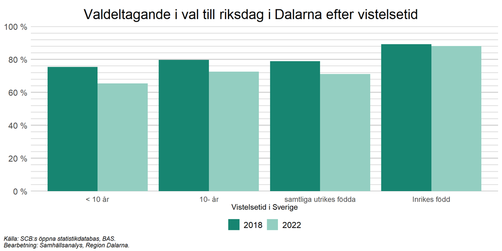

.

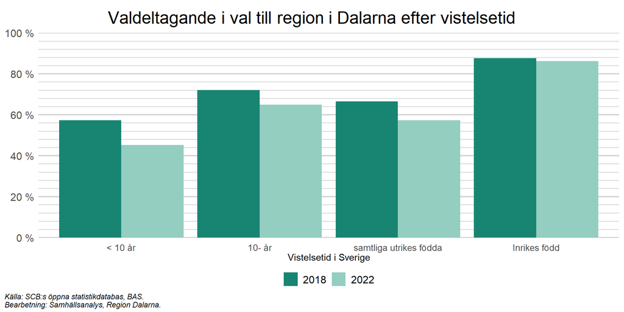

.

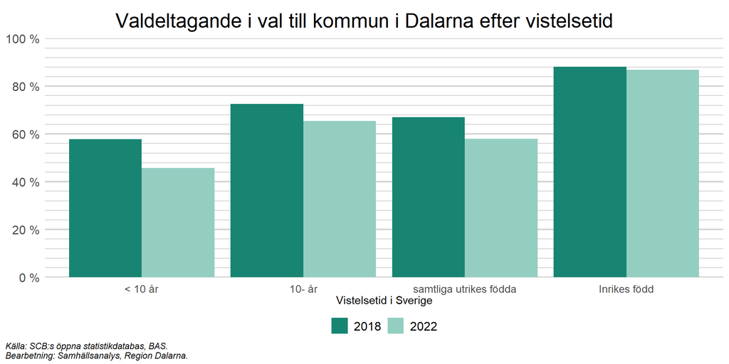

.

*SoM-institutets tillitsmätningar*

# 8 Sammanfattande diskussion

Vad ser vi ur ett integrationsperspektiv?

Vad är positivt? Vad är negativt?

Hur går det i skolan? Hur kommer de i arbete? Var jobbar de? Hur har det ekonomiska biståndet utvecklats? Hur går det med demokratin och tilliten till institutioner? Hur skulle Dalarna se ut, utan de utrikes födda?

[(Regeringen, 2022)](https://www.regeringen.se/contentassets/46945970585240a4a5bfd9a0f75ecf3d/ekonomisk-jamstalldhet.pdf)[^9]

# 9 Referenser

[^1]: Amnå, Erik och Stigendal, Mikael. Samhällsorientering : för en hållbar integration. Komlitt AB, Helsingborg. 2021.
[^2]: Region Dalarna. Nulägesbeskrivning av integrationen i Dalarna, ett regionalt perspektiv. Regionala utvecklingsförvaltningens rapportserie #1, 2019.
[^3]: Regeringen. Pressbriefing om migrationen till Sverige under 2024. 2025-01-10.
[^4]: Befolkningsutvecklingen i Dalarna, Samhällsanalys, Region Dalarna (2025-03-25).
[^5]: Expertgruppen för studier i offentlig ekonomi (2021)
[^6]: Jämställdhetsmyndigheten (2022)
[^7]: Expertgruppen för studier i offentlig ekonomi (2021)
[^8]: Etablering för fler – jämställda möjligheter till integration (SOU 2023:24)
[^9]: Regeringen, Budgetproposition 2022/23:1 bilaga 3, Ekonomisk jämställdhet.